# Milestone Report

23 June 2018

## Abstract

The goal of this report is to present the strategy to use a corpus of text in order to predict the next word in a sentence. This report is divided into three main parts:

1. Data acquisition
2. Data analysis
3. Data prediction

## Corpus reading

First we load the libraries used for the text mining and the data manipulation

```r
library("tm")
library(ggplot2)
library(reshape)
library(dplyr)
library(RWeka)
library(stringr)

#source("https://bioconductor.org/biocLite.R")
#biocLite("Rgraphviz")
library(Rgraphviz)

set.seed(12345)
```

Then we download the corpus. For this report we will only use a subset of the original data. This option could be switch off. After that, the text is read and place into a Corpus.

```r
#download.file(url="https://d396qusza40orc.cloudfront.net/dsscapstone/dataset/Coursera-SwiftKey.zip", destfile = "Coursera-SwiftKey.zip")
unzip("Coursera-SwiftKey.zip")

useSubDataSet = TRUE
if(useSubDataSet){
    #create a sub dataset with the 200th first lines of each files
    system("mkdir ./final/en_US_200/")
    system("head -200 ./final/en_US/en_US.blogs.txt > ./final/en_US_200/en_US.blogs.txt_200")
    system("head -200 ./final/en_US/en_US.news.txt > ./final/en_US_200/en_US.news.txt_200")
    system("head -200 ./final/en_US/en_US.twitter.txt > ./final/en_US_200/en_US.twitter.txt_200")

    ovid <- Corpus(DirSource("./final/en_US_200/"), readerControl = list(language = "en", load = TRUE))
}else{
    ovid <- Corpus(DirSource("./final/en_US/"), readerControl = list(language = "en", load = TRUE))
}
```

## Corpus overview

To look more closely at the corpus, we can count the numbers of words and characters.

```r
counts <- data.frame(row.names = names(ovid))
counts$words <- sapply(lapply(ovid, words),length)
counts$char <- sapply(ovid, nchar)
counts
```

```
##                       words  char
## en_US.blogs.txt_200    9447 52304
## en_US.news.txt_200     6589 39210
## en_US.twitter.txt_200  2382 12895
```

To better understand the numbers we can plot them:

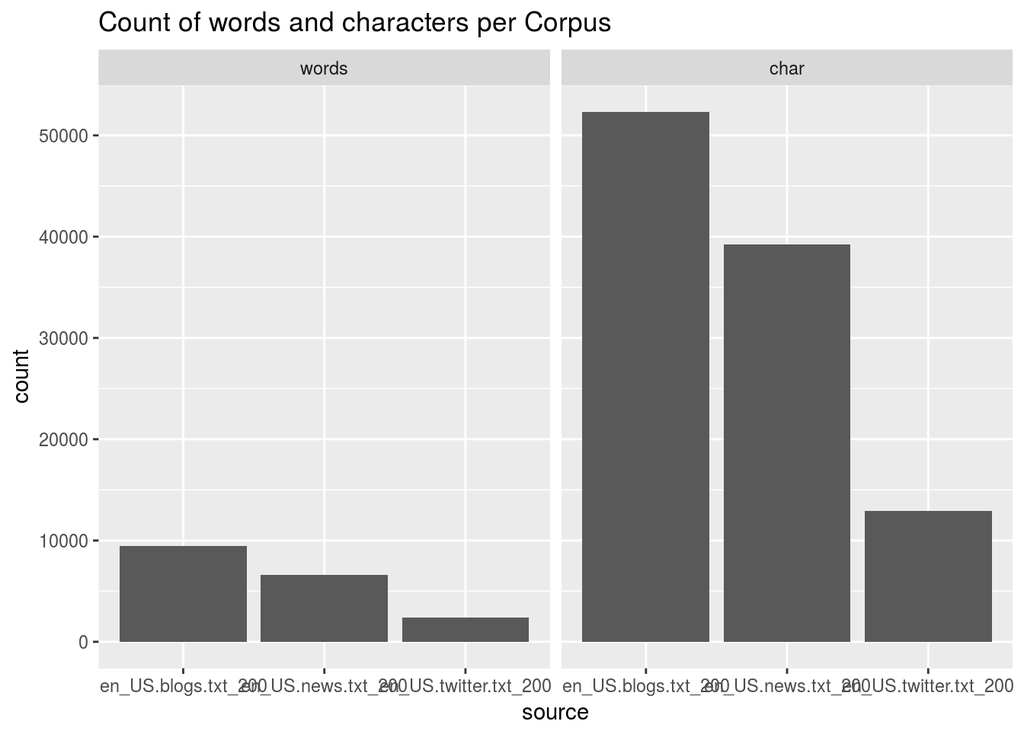

```r
ggplot( melt(cbind(source=row.names(counts), counts), id=c("source")) , aes(x=factor(source), y=value)) +
    geom_bar(stat = "identity")+
    facet_wrap(~variable) +
    labs(y = "count", x = "source", title = "Count of words and characters per Corpus")
```

## Corpus Analysis

The second part will be the analysis of the corpus. First we will parse the document and count the terms. For this counting we remove the punctuation, the numbers, and the English stop words.

```r
tdm <- TermDocumentMatrix(ovid, control = list(removePunctuation = TRUE, stopwords = TRUE, removeNumbers = TRUE,  stemming = TRUE))
```

```r
inspect(tdm[findFreqTerms(tdm, 25, Inf), 1:3])
```

```
## <<TermDocumentMatrix (terms: 24, documents: 3)>>
## Non-/sparse entries: 72/0
## Sparsity           : 0%
## Maximal term length: 5
## Weighting          : term frequency (tf)
## Sample             :
##       Docs
## Terms  en_US.blogs.txt_200 en_US.news.txt_200 en_US.twitter.txt_200
##   can                   17                  9                    14
##   get                   28                 16                     8
##   just                  31                 10                    13
##   like                  41                 14                    13
##   make                  25                 17                     4
##   new                   13                 18                     8
##   one                   34                 13                     6
##   said                   9                 56                     1
##   time                  41                 17                     8
##   will                  31                 16                    11
```

We can also visualize the correlations between terms of a term-document matrix.

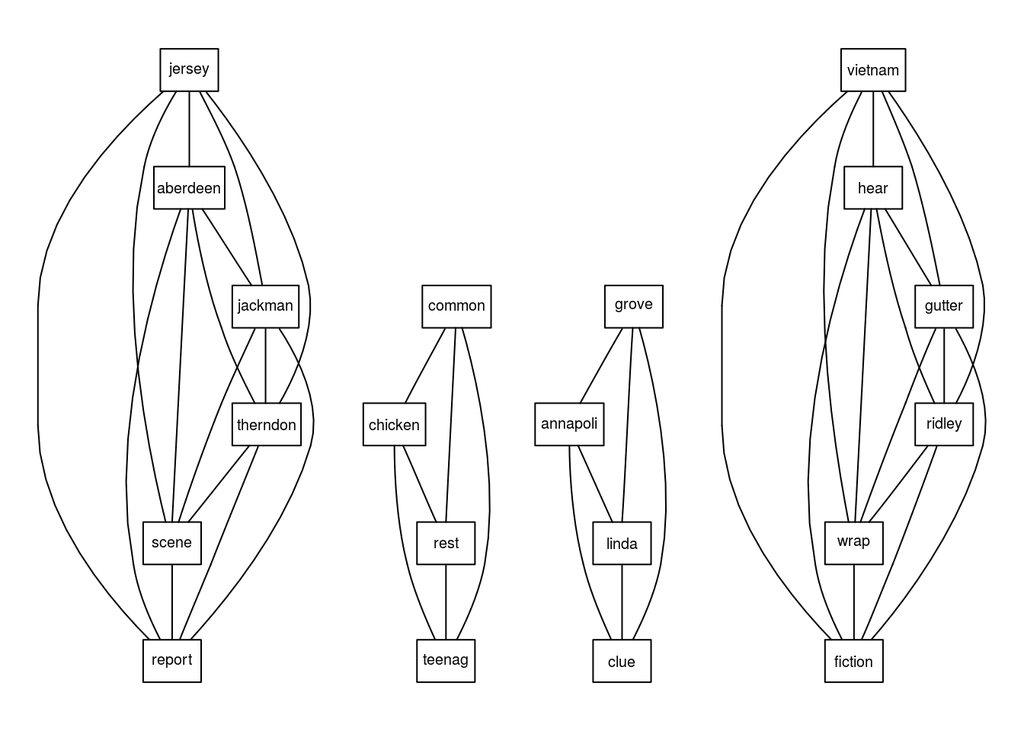

```r
plot(tdm)
```

## Prediction

### Tokenization

The first step for the prediction will be to tokenise the corpus to understand the sequences of the words. In order to save time in each tokenization we execute the previous transformation directly in the corpus.

```r
#cleaning the corpus
ovid <- tm_map(ovid, PlainTextDocument)
ovid <- tm_map(ovid, tolower)
ovid <- tm_map(ovid, stripWhitespace)
ovid <- tm_map(ovid,removePunctuation)
ovid <- tm_map(ovid, removeNumbers)
ovid <- tm_map(ovid, removeWords,stopwords("english"))
#Vcropus is mandatory for the tokenization
ovid <- VCorpus(VectorSource(ovid))
```

Then we can create three n-gram, one containing two words, one three and the last one between 4 and 5.

```r
#bigram
bigramTokenizer <- function(x) NGramTokenizer(x, Weka_control(min = 2, max = 2))
tdm_bigram <- TermDocumentMatrix(ovid, control = list(tokenize = bigramTokenizer))

frequency_bigram <- data.frame(row.names = rownames(tdm_bigram))
frequency_bigram$words <- rownames(tdm_bigram)
frequency_bigram$frequency <- rowSums(as.matrix(tdm_bigram))
frequency_bigram$type <- "bigram"
frequency_bigram <- arrange(frequency_bigram, desc(frequency))

#trigram
trigramTokenizer <- function(x) NGramTokenizer(x, Weka_control(min = 3, max = 3))
tdm_trigram <- TermDocumentMatrix(ovid, control = list(tokenize = trigramTokenizer))

frequency_trigram <- data.frame(row.names = rownames(tdm_trigram))
frequency_trigram$words <- rownames(tdm_trigram)
frequency_trigram$frequency <- rowSums(as.matrix(tdm_trigram))
frequency_trigram$type <- "trigram"
frequency_trigram <- arrange(frequency_trigram, desc(frequency))

#ngram
ngramTokenizer <- function(x) NGramTokenizer(x, Weka_control(min = 4, max = 5))
tdm_ngram <- TermDocumentMatrix(ovid, control = list(tokenize = ngramTokenizer))

frequency_ngram <- data.frame(row.names = rownames(tdm_ngram))
frequency_ngram$words <- rownames(tdm_ngram)
frequency_ngram$frequency <- rowSums(as.matrix(tdm_ngram))
frequency_ngram$type <- "ngram"
frequency_ngram <- arrange(frequency_ngram, desc(frequency))
```

After the set-up of the frequency data frame for each ngram we can plot the bigram and the trigram to better understand the data.

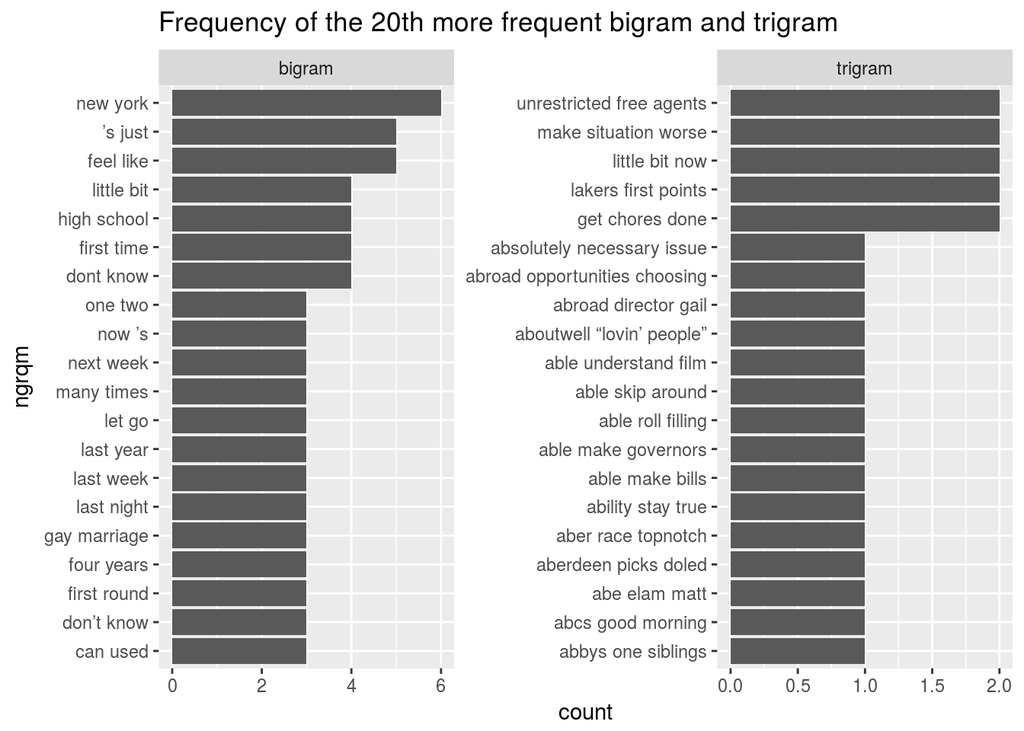

```r
ggplot(rbind(frequency_bigram[1:20,], frequency_trigram[1:20,]) , aes(x=reorder(words, frequency), y=frequency)) +
    geom_bar(stat = "identity")+
     coord_flip() +
    facet_wrap(~type, scales = "free") +
    labs(y = "count", x = "ngrqm", title = "Frequency of the 20th more frequent bigram and trigram")
```

### Model

The last part consist of building a model used for the prediction. This model will contain all the ngrqm frequencies for each ngrams. We will be able to use this model to predict:

- The second word knowing one word
- The third word knowing two words
- Etc.

```r
predict_model <- rbind(frequency_bigram, frequency_trigram, frequency_ngram)
predict_model <- cbind(predict_model, as.data.frame(str_split_fixed(predict_model[,1], pattern = " ", n = 5)))
predict_model <- select(predict_model, -words)
predict_model[sample(1:nrow(predict_model),10),]
```

```
##       frequency    type             V1        V2       V3       V4    V5
## 18356         1 trigram       straying  sidewalk  message
## 13219         1 trigram    frustration  striking     game
## 39053         1   ngram      versatile   italian     dish enhanced
## 28619         1   ngram          isn’t    simple    smart     stay facts
## 26072         1   ngram       findings  indicate landmark   shifts
## 15769         1 trigram            new      band     blog
## 28255         1   ngram implementation wordpress     fouc    dyall think
## 22006         1   ngram           book      feel    paper  fingers
## 9160          1  bigram   universities     drage
## 19598         1 trigram          water       can     used
```